# Homework 5

Jules Pellin

2026-05-18

# Question 1

```r
# Load required packages
library(readxl)
library(tidyverse)

# Read COVID and demographic data (files are Excel format despite .csv extension)
covid <- read_excel("US-cnty-COVID.csv")
demo  <- read_excel("US-cnty-demo.csv")

# Examine both files
head(covid)
```

```
## # A tibble: 6 × 4
##   State   County  Cases Deaths
##   <chr>   <chr>   <dbl>  <dbl>
## 1 Alabama Autauga  2456     36
## 2 Alabama Baldwin  7646     84
## 3 Alabama Barbour  1128      9
## 4 Alabama Bibb      986     17
## 5 Alabama Blount   2549     34
## 6 Alabama Bullock   677     19
```

```r
head(demo)
```

```
## # A tibble: 6 × 4
##   County.name ST.Name Pop.Over65 TotalPop
##   <chr>       <chr>        <dbl>    <dbl>
## 1 Autauga     Alabama       8050    55200
## 2 Baldwin     Alabama      40665   208107
## 3 Barbour     Alabama       4634    25782
## 4 Bibb        Alabama       3661    22527
## 5 Blount      Alabama      10233    57645
## 6 Bullock     Alabama       1616    10352
```

```r
str(covid)
```

```
## tibble [3,142 × 4] (S3: tbl_df/tbl/data.frame)
##  $ State : chr [1:3142] "Alabama" "Alabama" "Alabama" "Alabama" ...
##  $ County: chr [1:3142] "Autauga" "Baldwin" "Barbour" "Bibb" ...
##  $ Cases : num [1:3142] 2456 7646 1128 986 2549 ...
##  $ Deaths: num [1:3142] 36 84 9 17 34 19 41 77 48 15 ...
```

```r
str(demo)
```

```
## tibble [3,142 × 4] (S3: tbl_df/tbl/data.frame)
##  $ County.name: chr [1:3142] "Autauga" "Baldwin" "Barbour" "Bibb" ...
##  $ ST.Name    : chr [1:3142] "Alabama" "Alabama" "Alabama" "Alabama" ...
##  $ Pop.Over65 : num [1:3142] 8050 40665 4634 3661 10233 ...
##  $ TotalPop   : num [1:3142] 55200 208107 25782 22527 57645 ...
```

```r
# Merge by BOTH county AND state to avoid duplicate county name bug
# (e.g. King County exists in both WA and TX)
merged <- merge(covid, demo,
                by.x = c("County", "State"),
                by.y = c("County.name", "ST.Name"))

# Verify row count — should still be 3,142
nrow(merged)
```

```
## [1] 3142
```

```r
# Create rate columns
merged$cases_per_pop    <- merged$Cases  / merged$TotalPop
merged$deaths_per_pop   <- merged$Deaths / merged$TotalPop
merged$deaths_per_senior <- merged$Deaths / merged$Pop.Over65

head(merged)
```

```
##      County          State Cases Deaths Pop.Over65 TotalPop cases_per_pop
## 1 Abbeville South Carolina   866     19       5066    24657    0.03512187
## 2    Acadia      Louisiana  3483    108       9003    62568    0.05566743
## 3  Accomack       Virginia  1255     21       7171    32742    0.03832997
## 4       Ada          Idaho 21561    208      60097   446052    0.04833741
## 5     Adair           Iowa   345      5       1566     7124    0.04842785
## 6     Adair       Kentucky   596     23          0    19241    0.03097552
##   deaths_per_pop deaths_per_senior
## 1   0.0007705723       0.003750493
## 2   0.0017261220       0.011996001
## 3   0.0006413780       0.002928462
## 4   0.0004663133       0.003461071
## 5   0.0007018529       0.003192848
## 6   0.0011953641               Inf
```

```r
# i) Arrange by cases per population (highest first)
cases_ranked <- arrange(merged, desc(cases_per_pop))
head(cases_ranked[, c("County", "State", "cases_per_pop")])
```

```
##          County        State cases_per_pop
## 1     Trousdale    Tennessee     0.1946098
## 2        Norton       Kansas     0.1813708
## 3 Chattahoochee      Georgia     0.1799016
## 4     Bon Homme South Dakota     0.1740565
## 5       Lincoln     Arkansas     0.1726177
## 6       Buffalo South Dakota     0.1612275
```

```r
# ii) Arrange by deaths per population (highest first)
deaths_ranked <- arrange(merged, desc(deaths_per_pop))
head(deaths_ranked[, c("County", "State", "deaths_per_pop")])
```

```
##     County        State deaths_per_pop
## 1     Gove       Kansas    0.007254677
## 2  Jerauld South Dakota    0.006407097
## 3  Hancock      Georgia    0.005272408
## 4  Emporia     Virginia    0.005203494
## 5    Galax     Virginia    0.004519434
## 6 Randolph      Georgia    0.004233103
```

```r
# iii) Arrange by deaths per senior population (highest first)
# Exclude counties where Pop.Over65 = 0 (division by zero gives Inf)
senior_ranked <- arrange(merged, desc(deaths_per_senior))
senior_ranked_clean <- senior_ranked[is.finite(senior_ranked$deaths_per_senior), ]
head(senior_ranked_clean[, c("County", "State", "deaths_per_senior")])
```

```
##        County      State deaths_per_senior
## 548   Emporia   Virginia        0.03185438
## 549  McKinley New Mexico        0.03150262
## 550 Roosevelt    Montana        0.02972750
## 551  Big Horn    Montana        0.02918782
## 552     Bronx   New York        0.02877285
## 553      Gove     Kansas        0.02718169
```

The three rankings reveal very different patterns of COVID burden across US counties.

Ranked by cases per population, small counties with large institutional populations top the list: prisons (Trousdale, TN; Norton, KS) and military bases (Chattahoochee, GA) explain the extreme rates, as these dense enclosed environments drive rapid transmission regardless of county size.

Ranked by deaths per population, a different set of small rural counties appears (Gove, KS; Jerauld, SD; Hancock, GA), likely reflecting older and more vulnerable local populations where fatality rates ran high even with fewer total cases.

The senior population ranking required filtering out counties with zero seniors recorded, which produced Inf values from division by zero. Once cleaned, this ranking surfaces Native American reservation counties (McKinley, NM; Big Horn, MT) and urban areas like the Bronx, NY, pointing to the disproportionate COVID toll on those communities.

No single metric tells the full story. The rankings diverge significantly depending on which dimension of burden is measured, which is exactly why looking at all three together matters.

# Question 2

```r
# Load all three World Bank files
wbh      <- read_csv("worldbankhealth.csv")
wbh_class <- read_csv("WorldBankCountryClassClean.csv")
wbh_desc  <- read_csv("WorldBankHealth-VarDescClean.csv")

# Examine each file
head(wbh)
```

```
## # A tibble: 6 × 6
##   country_name           country_code indicator_name indicator_code  year  value
##   <chr>                  <chr>        <chr>          <chr>          <dbl>  <dbl>
## 1 Middle East & North A… TMN          Population ag… SP.POP.65UP.M…  1977 2.60e6
## 2 Armenia                ARM          Nurses and mi… SH.MED.NUMW.P3  2006 4.92e0
## 3 Georgia                GEO          Male populati… SP.POP.2529.MA  1965 1.69e5
## 4 Tanzania               TZA          Labor force, … SL.TLF.TOTL.IN  2015 2.30e7
## 5 Cambodia               KHM          Age populatio… SP.POP.AG16.F…  1991 8.46e4
## 6 Mongolia               MNG          Female popula… SP.POP.2024.FE  1989 1.06e5
```

```r
str(wbh)
```

```
## spc_tbl_ [2,520,849 × 6] (S3: spec_tbl_df/tbl_df/tbl/data.frame)
##  $ country_name  : chr [1:2520849] "Middle East & North Africa (IDA & IBRD countries)" "Armenia" "Georgia" "Tanzania" ...
##  $ country_code  : chr [1:2520849] "TMN" "ARM" "GEO" "TZA" ...
##  $ indicator_name: chr [1:2520849] "Population ages 65 and above, male" "Nurses and midwives (per 1,000 people)" "Male population 25-29" "Labor force, total" ...
##  $ indicator_code: chr [1:2520849] "SP.POP.65UP.MA.IN" "SH.MED.NUMW.P3" "SP.POP.2529.MA" "SL.TLF.TOTL.IN" ...
##  $ year          : num [1:2520849] 1977 2006 1965 2015 1991 ...
##  $ value         : num [1:2520849] 2.60e+06 4.92 1.69e+05 2.30e+07 8.46e+04 ...
##  - attr(*, "spec")=
##   .. cols(
##   ..   country_name = col_character(),
##   ..   country_code = col_character(),
##   ..   indicator_name = col_character(),
##   ..   indicator_code = col_character(),
##   ..   year = col_double(),
##   ..   value = col_double()
##   .. )
##  - attr(*, "problems")=<externalptr>
```

```r
head(wbh_class)
```

```
## # A tibble: 6 × 5
##   country.name   country.code region                     income.group   lend.cat
##   <chr>          <chr>        <chr>                      <chr>          <chr>
## 1 Afghanistan    AFG          South Asia                 Low income     IDA
## 2 Albania        ALB          Europe & Central Asia      Upper middle … IBRD
## 3 Algeria        DZA          Middle East & North Africa Upper middle … IBRD
## 4 American Samoa ASM          East Asia & Pacific        Upper middle … no.lend
## 5 Andorra        AND          Europe & Central Asia      High income    no.lend
## 6 Angola         AGO          Sub-Saharan Africa         Lower middle … IBRD
```

```r
head(wbh_desc)
```

```
## # A tibble: 6 × 3
##   series_code          indicator_name                            long_definition
##   <chr>                <chr>                                     <chr>
## 1 NY.GNP.PCAP.CD       GNI per capita, Atlas method (current US… GNI per capita…
## 2 SE.ADT.1524.LT.FM.ZS Literacy rate, youth (ages 15-24), gende… Gender parity …
## 3 SE.ADT.1524.LT.MA.ZS Literacy rate, youth male (% of males ag… Youth literacy…
## 4 SE.ADT.1524.LT.ZS    Literacy rate, youth total (% of people … Youth literacy…
## 5 SE.ADT.LITR.FE.ZS    Literacy rate, adult female (% of female… Adult literacy…
## 6 SE.ADT.LITR.MA.ZS    Literacy rate, adult male (% of males ag… Adult literacy…
```

```r
# Remove country_name and indicator_name — codes already capture this info
wbh2 <- wbh %>% select(-country_name, -indicator_name)

# Pivot wider: one row per country per year, each indicator becomes a column
wbh_wide <- wbh2 %>%
  pivot_wider(names_from = indicator_code, values_from = value)

# Examine the result
dim(wbh_wide)
```

```
## [1] 14705   348
```

```r
head(wbh_wide[, 1:6])
```

```
## # A tibble: 6 × 6
##   country_code  year SP.POP.65UP.MA.IN SH.MED.NUMW.P3 SP.POP.2529.MA
##   <chr>        <dbl>             <dbl>          <dbl>          <dbl>
## 1 TMN           1977           2598418          NA           5297234
## 2 ARM           2006            145113           4.92         115406
## 3 GEO           1965            130312          NA            169351
## 4 TZA           2015            795398          NA           1943276
## 5 KHM           1991            111565          NA            313285
## 6 MNG           1989             39976          NA             89419
## # ℹ 1 more variable: SL.TLF.TOTL.IN <dbl>
```

```r
# Count NAs per column
na_counts <- apply(is.na(wbh_wide), MARGIN = 2, sum)

# Convert to data frame and sort by fewest NAs
na_df <- data.frame(column = names(na_counts), na_count = na_counts) %>%
  arrange(na_count)

head(na_df, 15)
```

```
##                              column na_count
## country_code           country_code        0
## year                           year        0
## SP.POP.TOTL             SP.POP.TOTL      109
## SP.RUR.TOTL.ZS       SP.RUR.TOTL.ZS      178
## SP.URB.TOTL.IN.ZS SP.URB.TOTL.IN.ZS      178
## SP.RUR.TOTL             SP.RUR.TOTL      222
## SP.URB.TOTL             SP.URB.TOTL      222
## SP.POP.GROW             SP.POP.GROW      368
## SP.URB.GROW             SP.URB.GROW      478
## SP.RUR.TOTL.ZG       SP.RUR.TOTL.ZG      873
## SP.DYN.CBRT.IN       SP.DYN.CBRT.IN     1249
## SP.DYN.CDRT.IN       SP.DYN.CDRT.IN     1289
## SP.POP.1564.FE.ZS SP.POP.1564.FE.ZS     1374
## SP.POP.TOTL.FE.ZS SP.POP.TOTL.FE.ZS     1374
## SP.POP.0014.TO.ZS SP.POP.0014.TO.ZS     1374
```

```r
# Select 11 columns with fewest NAs
top11_cols <- na_df$column[1:11]
wbh_final <- wbh_wide %>% select(all_of(top11_cols))

dim(wbh_final)
```

```
## [1] 14705    11
```

```r
head(wbh_final)
```

```
## # A tibble: 6 × 11
##   country_code  year SP.POP.TOTL SP.RUR.TOTL.ZS SP.URB.TOTL.IN.ZS SP.RUR.TOTL
##   <chr>        <dbl>       <dbl>          <dbl>             <dbl>       <dbl>
## 1 TMN           1977   153077841           54.6              45.4    83611640
## 2 ARM           2006     3002161           35.8              64.2     1076275
## 3 GEO           1965     3921600           54.5              45.5     2135939
## 4 TZA           2015    53470420           68.4              31.6    36569490
## 5 KHM           1991     9323607           84.1              15.9     7842366
## 6 MNG           1989     2141006           42.9              57.1      918963
## # ℹ 5 more variables: SP.URB.TOTL <dbl>, SP.POP.GROW <dbl>, SP.URB.GROW <dbl>,
## #   SP.RUR.TOTL.ZG <dbl>, SP.DYN.CBRT.IN <dbl>
```

Removing the two name columns keeps things cleaner since the codes already identify each country and indicator. After pivoting wider, each indicator gets its own column with one row per country per year. As expected, a lot of NAs show up since not every country reports every indicator every year. The 11 columns with the fewest NAs all turn out to be population and urbanization indicators, which makes sense as those tend to be the most consistently reported across countries.

# Question 3 - Box Plots

## Sepal width - base R

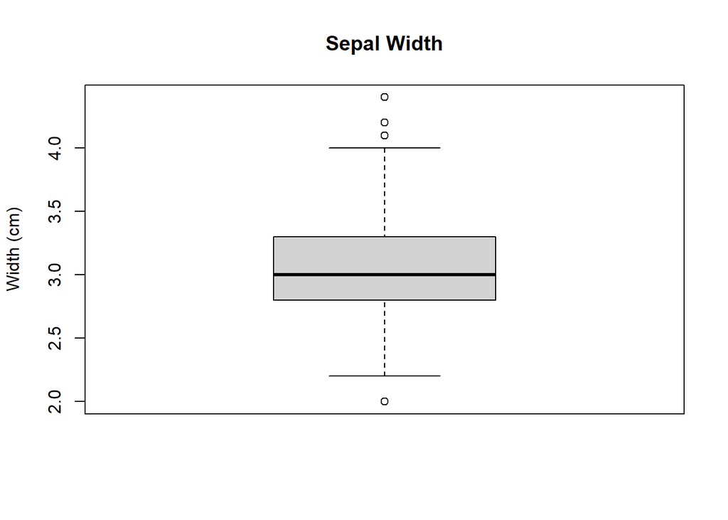

```r
# Base R box plot of sepal width as instructed
boxplot(iris$Sepal.Width,
        main = "Sepal Width",
        ylab = "Width (cm)")
```

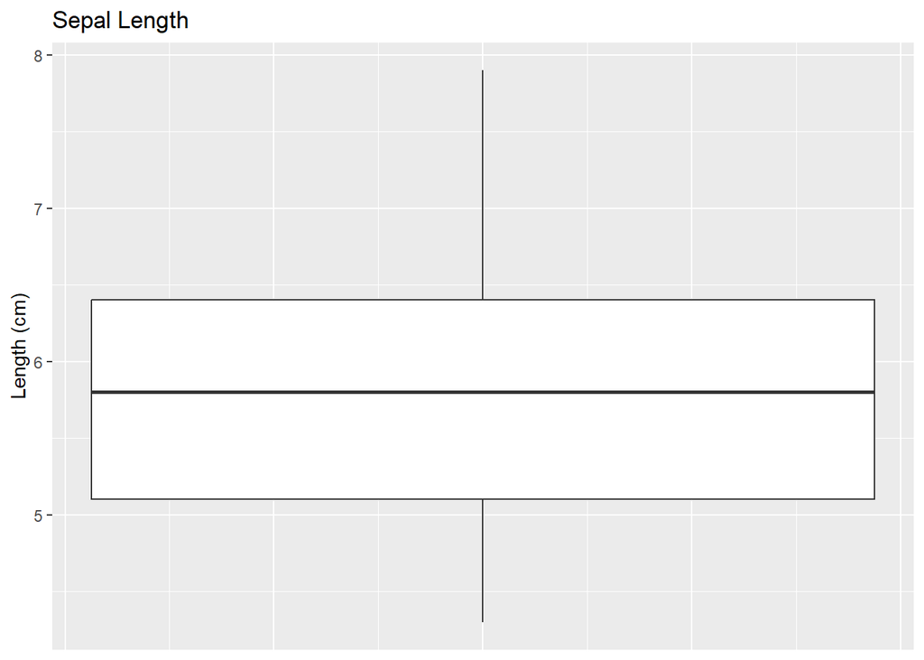

```r
# Vertical orientation is cleaner for a single variable
ggplot(iris, aes(y = Sepal.Length)) +
  geom_boxplot() +
  labs(title = "Sepal Length",
       y = "Length (cm)") +
  theme(axis.text.x = element_blank(),
        axis.ticks.x = element_blank())
```

Sepal length across all iris observations has a median around 5.8 cm with the middle 50% of values falling between roughly 5.1 and 6.4 cm. The distribution is fairly symmetric with no obvious outliers, and the whiskers extend from about 4.3 to 7.9 cm.

## Petal length vs class - ggplot

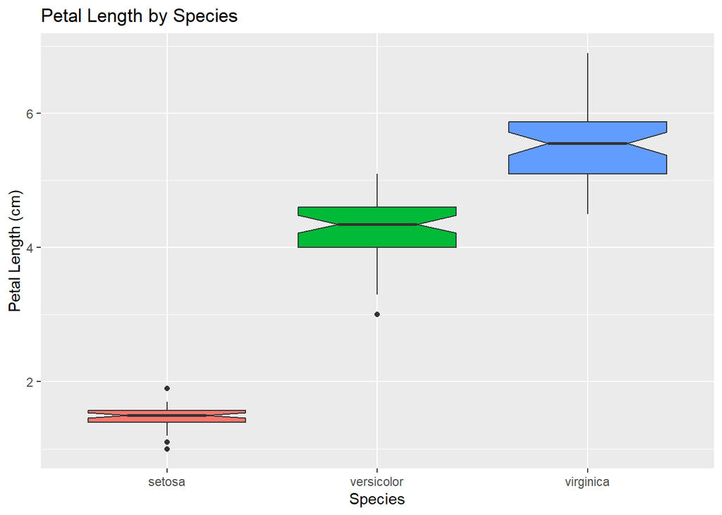

```r
# Notched box plot of petal length by species, colored by species
ggplot(iris, aes(x = Species, y = Petal.Length, fill = Species)) +
  geom_boxplot(notch = TRUE) +
  labs(title = "Petal Length by Species",
       x = "Species",
       y = "Petal Length (cm)") +
  theme(legend.position = "none")
```

## Petal width vs class - strip, jitter and violin

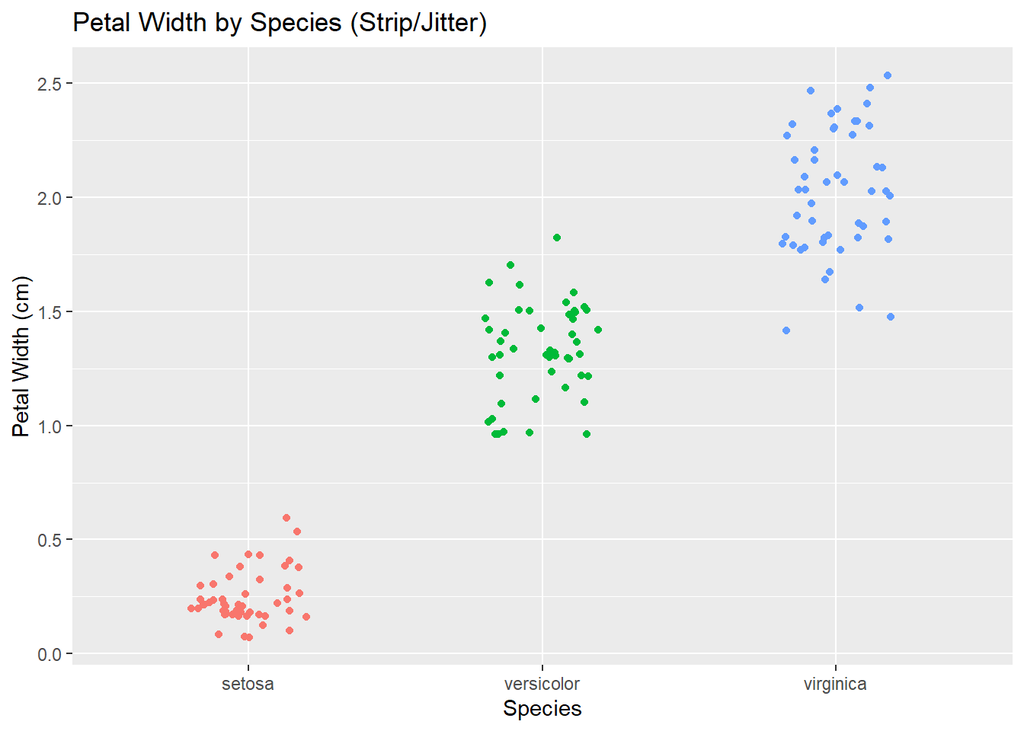

```r
# Strip plot
ggplot(iris, aes(x = Species, y = Petal.Width, color = Species)) +
  geom_jitter(width = 0.2) +
  labs(title = "Petal Width by Species (Strip/Jitter)",
       x = "Species", y = "Petal Width (cm)") +
  theme(legend.position = "none")
```

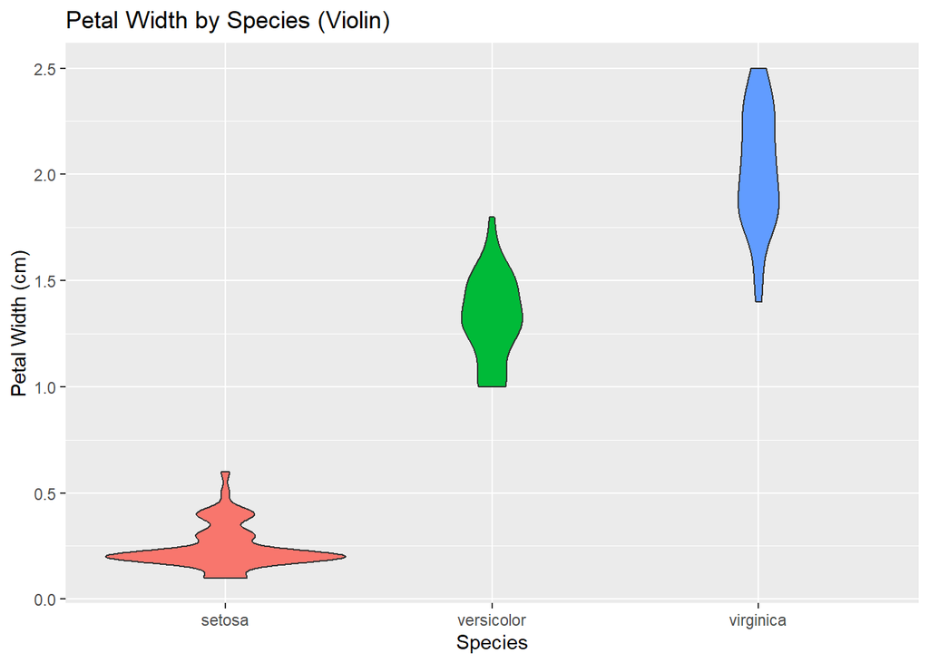

```r
# Violin plot
ggplot(iris, aes(x = Species, y = Petal.Width, fill = Species)) +
  geom_violin() +
  labs(title = "Petal Width by Species (Violin)",
       x = "Species", y = "Petal Width (cm)") +
  theme(legend.position = "none")
```

The jitter and violin plots tell the same story as the petal length analysis. Setosa stands out immediately with petals clustered tightly at around 0.2 cm — the jitter plot especially shows just how little variation there is across all 50 observations. Versicolor sits in the middle with values centered around 1.3 cm, and virginica has the widest petals, spreading mostly between 1.5 and 2.5 cm. The violin shapes are worth noting too: setosa looks almost flat and pancake-like because nearly all its values land at the same point, while virginica stretches tall showing more range in the data.

# Question 4 - Histograms

## Sepal width - base R

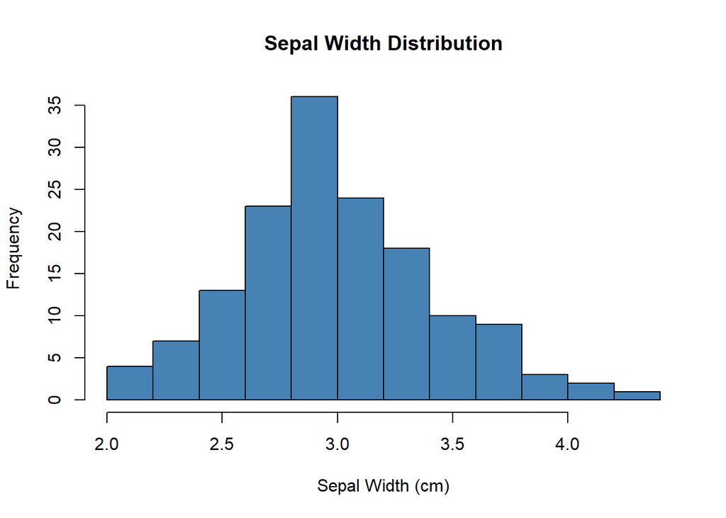

```r
# Base R frequency histogram of sepal width as instructed
hist(iris$Sepal.Width,
     main = "Sepal Width Distribution",
     xlab = "Sepal Width (cm)",
     col  = "steelblue")
```

Sepal width is centered around 3.0 cm and has a pretty classic bell shape, ranging from about 2.0 to 4.4 cm. The tallest bar lands right at 3.0 with around 35 observations. There is a slight right skew with a longer tail on the upper end, but overall the distribution is fairly symmetric.

## Sepal length - ggplot frequency histogram + polygon

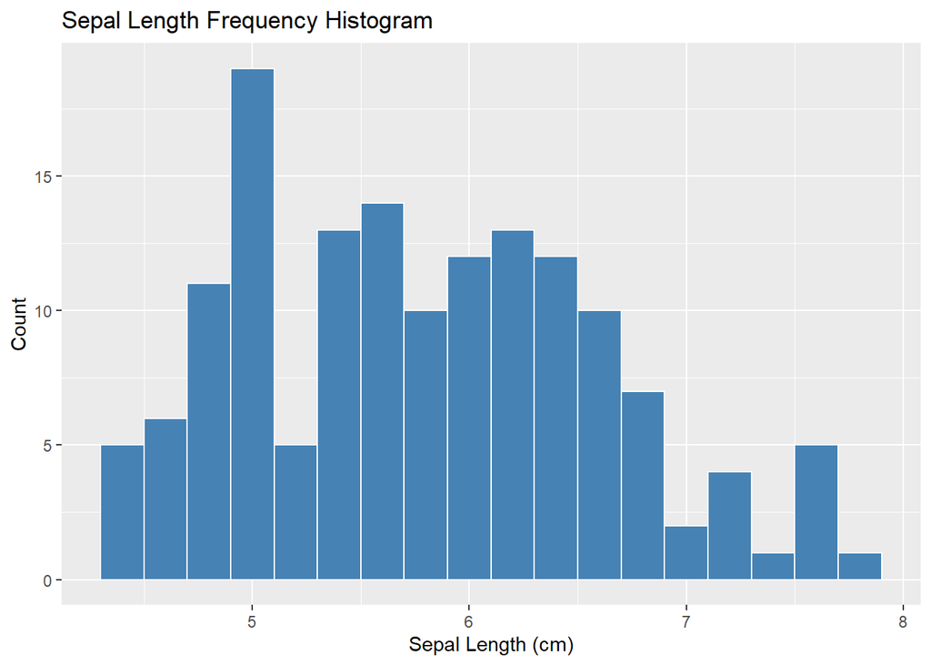

```r
# Part 1: Frequency histogram
# binwidth = 0.2 is the smallest that avoids empty bins
ggplot(iris, aes(x = Sepal.Length)) +
  geom_histogram(binwidth = 0.2, fill = "steelblue", color = "white") +
  labs(title = "Sepal Length Frequency Histogram",
       x = "Sepal Length (cm)",
       y = "Count")
```

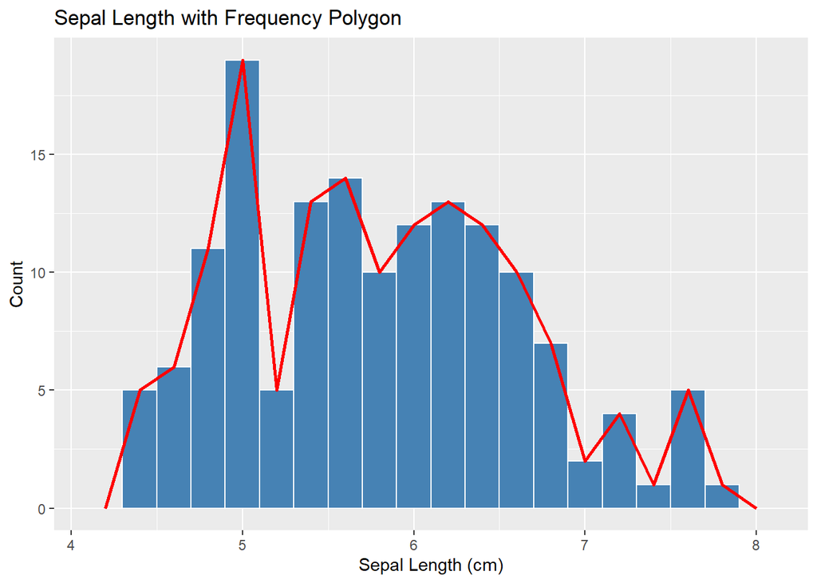

```r
# Part 2: Frequency polygon overlaid on histogram
ggplot(iris, aes(x = Sepal.Length)) +
  geom_histogram(binwidth = 0.2, fill = "steelblue", color = "white") +
  geom_freqpoly(binwidth = 0.2, color = "red", linewidth = 1) +
  labs(title = "Sepal Length with Frequency Polygon",
       x = "Sepal Length (cm)",
       y = "Count")
```

Sepal length ranges from about 4.3 to 7.9 cm with the tallest bar landing at 5.0 cm. Rather than one clean peak, the distribution has two humps, which makes sense given that the three species have quite different sepal lengths pulling the overall shape apart. The frequency polygon traces that pattern nicely, making the rises and dips between bins easier to follow at a glance.

## Petal length - density histogram + kernel density

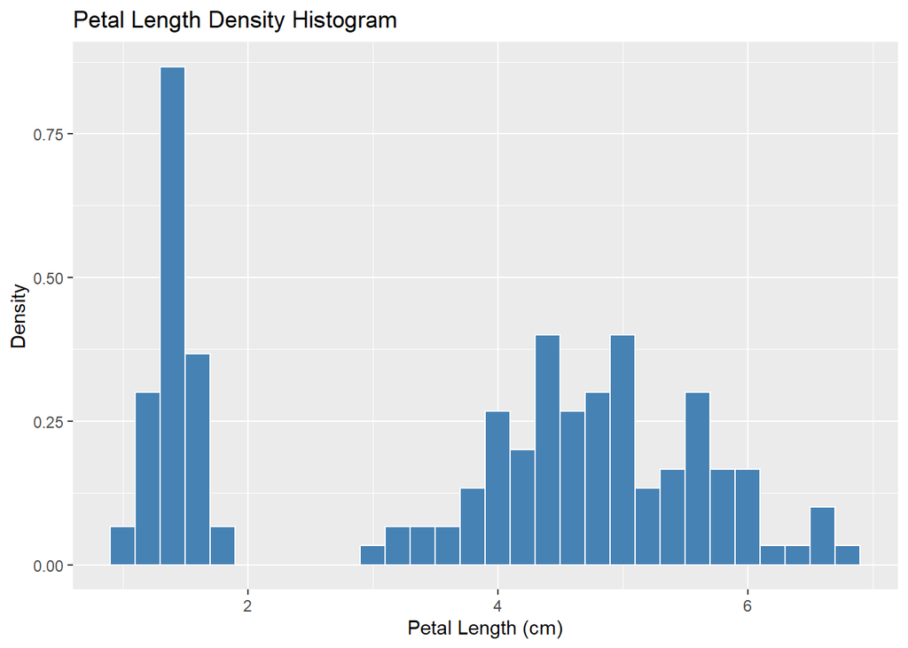

```r
# Part 1: Density histogram
# binwidth = 0.2 is the smallest that avoids empty bins
ggplot(iris, aes(x = Petal.Length)) +
  geom_histogram(aes(y = after_stat(density)),
                 binwidth = 0.2, fill = "steelblue", color = "white") +
  labs(title = "Petal Length Density Histogram",
       x = "Petal Length (cm)",
       y = "Density")
```

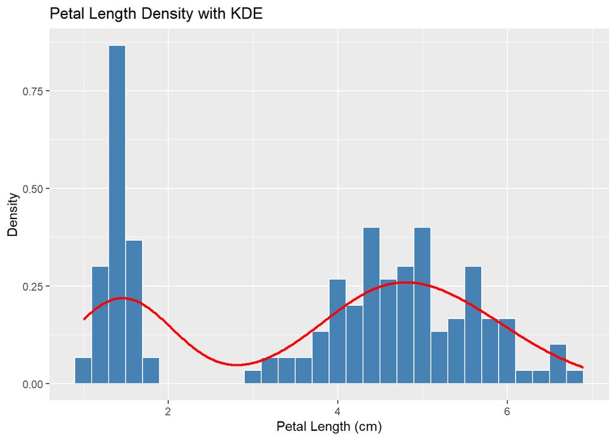

```r
# Part 2: Kernel density estimator overlaid
ggplot(iris, aes(x = Petal.Length)) +
  geom_histogram(aes(y = after_stat(density)),
                 binwidth = 0.2, fill = "steelblue", color = "white") +
  geom_density(color = "red", linewidth = 1) +
  labs(title = "Petal Length Density with KDE",
       x = "Petal Length (cm)",
       y = "Density")
```

Petal length has a very clear two-humped shape, a tall narrow spike around 1.0 to 1.5 cm and a broader second hump stretching from about 3.5 to 6.5 cm. That gap in the middle is setosa completely separated from the other two species. The KDE line smooths over the bin-by-bin noise and makes the bimodal structure even more obvious, though it undersells the height of the setosa spike since it is spreading the density across a wider range than the actual data.

## Petal width by class - faceted histogram + polygon

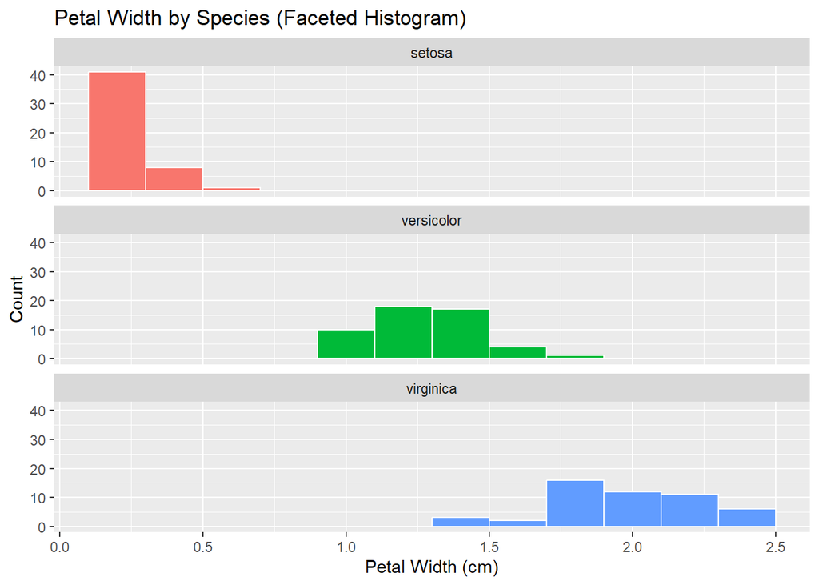

```r
# Part 1: Faceted frequency histogram, vertical orientation
ggplot(iris, aes(x = Petal.Width, fill = Species)) +
  geom_histogram(binwidth = 0.2, color = "white") +
  facet_wrap(~ Species, ncol = 1) +
  labs(title = "Petal Width by Species (Faceted Histogram)",
       x = "Petal Width (cm)",
       y = "Count") +
  theme(legend.position = "none")
```

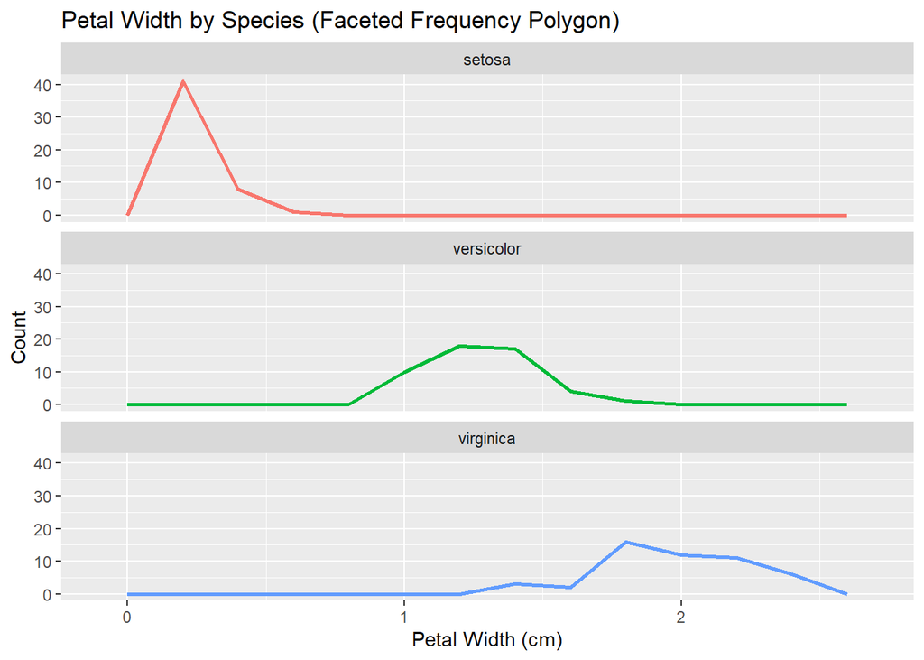

```r
# Part 2: Faceted frequency polygon
ggplot(iris, aes(x = Petal.Width, color = Species)) +
  geom_freqpoly(binwidth = 0.2, linewidth = 1) +
  facet_wrap(~ Species, ncol = 1) +
  labs(title = "Petal Width by Species (Faceted Frequency Polygon)",
       x = "Petal Width (cm)",
       y = "Count") +
  theme(legend.position = "none")
```

Breaking petal width out by species makes the differences really obvious. Setosa spikes sharply right at 0.2 cm and drops off almost immediately, confirming how tightly packed its values are. Versicolor has a much smoother, wider curve centered around 1.3 cm with a fairly even spread on both sides. Virginica is the most spread out of the three, with values running from about 1.4 to 2.5 cm and a flatter peak around 2.0 cm. The faceted layout makes it easy to compare the shapes side by side without the species overlapping and cluttering each other.